# Exploratory Data Analysis

Sam Burk

2024-01-23

# Background

We’re going to explore a large data set or traffic crashes to learn about what factors are connected with injuries. We will use data from the city of [Chicago’s open data portal](https://data.cityofchicago.org/Transportation/Traffic-Crashes-Crashes/85ca-t3if/about_data). (This activity is derived from a [blog post](https://juliasilge.com/blog/chicago-traffic-model/) by Julia Silge)

```r
years_ago <- mdy("01/01/2022") # data from last 2 years. May take time to load!
crash_url <- glue::glue("https://data.cityofchicago.org/Transportation/Traffic-Crashes-Crashes/85ca-t3if?$where=CRASH_DATE >= '{years_ago}'")
crash_raw <- as_tibble(read.socrata(crash_url)) # a new way to read in data, don't worry about it!
```

This dataset is pretty crazy! Take a look at it in the viewer, and then let’s do some data munging to get it into a nicer form.

-create a variable called `injuries` which indicates if the crash involved injuries or not. -create an unknown category for missing `report_type`s -decide which other variables to keep

```r
crash <- crash_raw %>%
  arrange(desc(crash_date)) %>%
  transmute(
    crash_date,
    injuries = as.factor(if_else(injuries_total > 0, "injuries", "none")),
    report_type = as.factor(replace(crash_raw$report_type, crash_raw$report_type=="", "UNKNOWN")),
    latitude, longitude,
    prim_contributory_cause,
    sec_contributory_cause,
    crash_month = as.factor(crash_month),
    weather_condition,
    lighting_condition,
    posted_speed_limit,
    injuries_total
  )
```

## Exploratory Data Analysis

Here’s a few questions to get you started.

1. Take a look at crashes by latitude and longitude, colored by injuries. What do you notice?

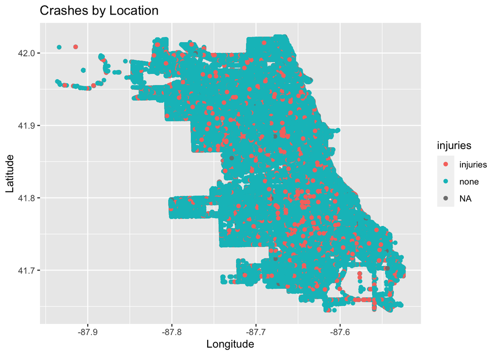

There doesn’t seem to be much correlation between the location of a crash and whether injuries were sustained. The crashes with injuries and crashes without are distributed evenly across Chicago.

2. What are the most common contributing factors to a crash?

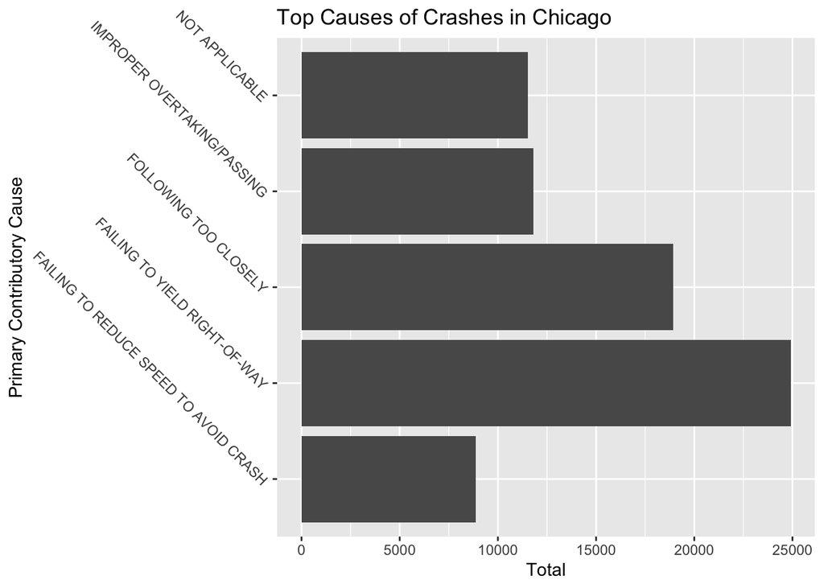

Failing to yield the right of way was the leading cause of crashes.

3. How do crashes vary month by month? Compare crashes by month in 2022 to 2023.

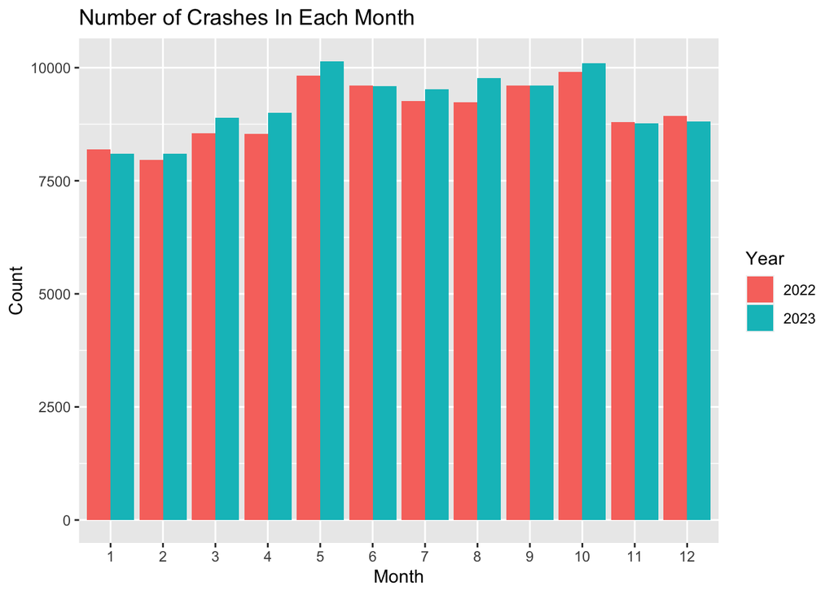

Crashes seem to peak in May and October, with higher numbers of crashes in the summer and fewer in the winter. There are small differences between 2022 and 2023, but they generally seem to be negligible.

4. Are crashes more likely to cause injuries when it is rainy and dark? Use the variables `weather_condition` and `lighting_condition` to explore.

[figure not shown]

[figure not shown]

The most frequent conditions to cause injuries are clear days, likely because that’s when the most people are driving.

5. Choose a question you want to explore, and create an appropriate visual.

Do crashes at higher speeds result in more injuries?

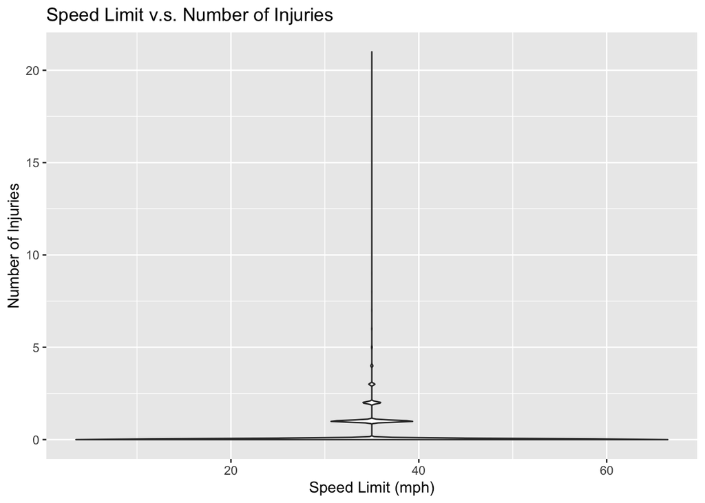